# STA 380 Homework 1

Pooshan Shah

August 8, 2018

```
##  [1]  0.27459028 -0.02857371  1.45856512  0.99038489  2.09651319
##  [6] -0.12090097 -0.08492216  0.21884096  0.34243960  0.76324466
```

```
##  [1]  1.0355153 -1.8963492 -0.6809532 -0.3328306 -0.9303412  0.7316681
##  [7] -1.2623699 -0.6749605  0.4671968 -1.0254782
```

```
##  [1]  0.156703769  1.373811191  0.730670244 -1.350800927 -0.008514961
##  [6]  0.320981863 -1.778148409  0.909503835 -0.919404336 -0.157714831
```

```
##  [1]  0.156703769  1.373811191  0.730670244 -1.350800927 -0.008514961
##  [6]  0.320981863 -1.778148409  0.909503835 -0.919404336 -0.157714831
```

## Exploratory Analysis: green buildings

Summary of Green Data:

```
##  CS_PropertyID        cluster            size            empl_gr
##  Min.   :      1   Min.   :   1.0   Min.   :   1624   Min.   :-24.950
##  1st Qu.: 157452   1st Qu.: 272.0   1st Qu.:  50891   1st Qu.:  1.740
##  Median : 313253   Median : 476.0   Median : 128838   Median :  1.970
##  Mean   : 453003   Mean   : 588.6   Mean   : 234638   Mean   :  3.207
##  3rd Qu.: 441188   3rd Qu.:1044.0   3rd Qu.: 294212   3rd Qu.:  2.380
##  Max.   :6208103   Max.   :1230.0   Max.   :3781045   Max.   : 67.780
##                                                       NA's   :74
##       Rent         leasing_rate       stories            age
##  Min.   :  2.98   Min.   :  0.00   Min.   :  1.00   Min.   :  0.00
##  1st Qu.: 19.50   1st Qu.: 77.85   1st Qu.:  4.00   1st Qu.: 23.00
##  Median : 25.16   Median : 89.53   Median : 10.00   Median : 34.00
##  Mean   : 28.42   Mean   : 82.61   Mean   : 13.58   Mean   : 47.24
##  3rd Qu.: 34.18   3rd Qu.: 96.44   3rd Qu.: 19.00   3rd Qu.: 79.00
##  Max.   :250.00   Max.   :100.00   Max.   :110.00   Max.   :187.00
##
##    renovated         class_a          class_b            LEED
##  Min.   :0.0000   Min.   :0.0000   Min.   :0.0000   Min.   :0.000000
##  1st Qu.:0.0000   1st Qu.:0.0000   1st Qu.:0.0000   1st Qu.:0.000000
##  Median :0.0000   Median :0.0000   Median :0.0000   Median :0.000000
##  Mean   :0.3795   Mean   :0.3999   Mean   :0.4595   Mean   :0.006841
##  3rd Qu.:1.0000   3rd Qu.:1.0000   3rd Qu.:1.0000   3rd Qu.:0.000000
##  Max.   :1.0000   Max.   :1.0000   Max.   :1.0000   Max.   :1.000000
##
##    Energystar       green_rating          net            amenities
##  Min.   :0.00000   Min.   :0.00000   Min.   :0.00000   Min.   :0.0000
##  1st Qu.:0.00000   1st Qu.:0.00000   1st Qu.:0.00000   1st Qu.:0.0000
##  Median :0.00000   Median :0.00000   Median :0.00000   Median :1.0000
##  Mean   :0.08082   Mean   :0.08677   Mean   :0.03471   Mean   :0.5266
##  3rd Qu.:0.00000   3rd Qu.:0.00000   3rd Qu.:0.00000   3rd Qu.:1.0000
##  Max.   :1.00000   Max.   :1.00000   Max.   :1.00000   Max.   :1.0000
##
##   cd_total_07     hd_total07    total_dd_07   Precipitation
##  Min.   :  39   Min.   :   0   Min.   :2103   Min.   :10.46
##  1st Qu.: 684   1st Qu.:1419   1st Qu.:2869   1st Qu.:22.71
##  Median : 966   Median :2739   Median :4979   Median :23.16
##  Mean   :1229   Mean   :3432   Mean   :4661   Mean   :31.08
##  3rd Qu.:1620   3rd Qu.:4796   3rd Qu.:6413   3rd Qu.:43.89
##  Max.   :5240   Max.   :7200   Max.   :8244   Max.   :58.02
##
##    Gas_Costs        Electricity_Costs  cluster_rent
##  Min.   :0.009487   Min.   :0.01780   Min.   : 9.00
##  1st Qu.:0.010296   1st Qu.:0.02330   1st Qu.:20.00
##  Median :0.010296   Median :0.03274   Median :25.14
##  Mean   :0.011336   Mean   :0.03096   Mean   :27.50
##  3rd Qu.:0.011816   3rd Qu.:0.03781   3rd Qu.:34.00
##  Max.   :0.028914   Max.   :0.06280   Max.   :71.44
##
```

Hypothesis: I do not agree with the approach the stats-guru took in finding the answer to the problem. There are other factors involved that could affect the rent and green status of a building. Some factors I believe that could be significant are: cluster_rent, gas/electricity costs, net, amenities, class, size, and leasing rate.

Extract the buildings with green ratings

```r
green_only = subset(green, green_rating==1)
not_green = subset(green, green_rating ==0)
```

### Basic EDA

Summary of Green Data Rent

```
##    Min. 1st Qu.  Median    Mean 3rd Qu.    Max.
##    2.98   19.50   25.16   28.42   34.18  250.00
```

Summary of only Green Buildings’ Rent

```
##    Min. 1st Qu.  Median    Mean 3rd Qu.    Max.
##    8.87   21.50   27.60   30.02   35.50  138.07
```

Summary of non-Green Buildings’ Rent

```
##    Min. 1st Qu.  Median    Mean 3rd Qu.    Max.
##    2.98   19.18   25.00   28.27   34.00  250.00
```

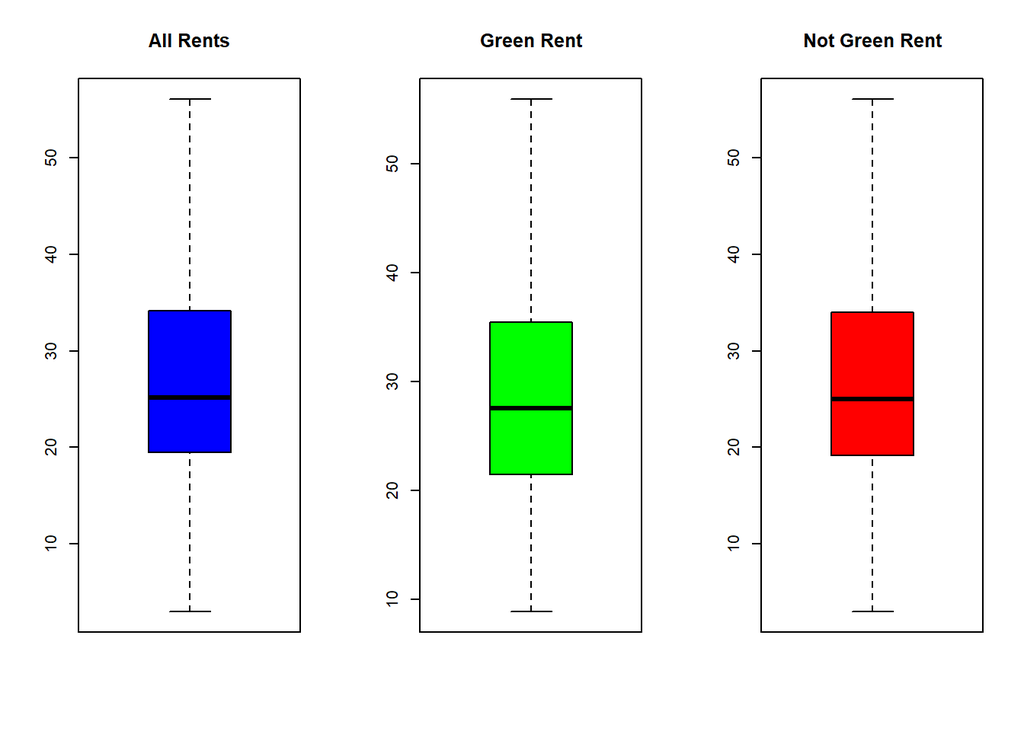

Comments: Here we get a sense of the green data as a whole, and once we split the data into green buildings, and non-green buildings, we can see holistically how they differ at the rent level. A difference is see-able between green and non-green rent.

```r
summary(green_only$size)
```

```
##    Min. 1st Qu.  Median    Mean 3rd Qu.    Max.
##   10560  120000  241150  325781  417446 1721242
```

```r
summary(not_green$size)
```

```
##    Min. 1st Qu.  Median    Mean 3rd Qu.    Max.
##    1624   46043  118696  225977  279411 3781045
```

Comments: the size of this bulding will be close to the median of all green buildings and between the mean and 3rd quartile for non-green.

```r
summary(green_only$age)
```

```
##    Min. 1st Qu.  Median    Mean 3rd Qu.    Max.
##    0.00   18.00   22.00   23.85   26.00  116.00
```

Comments: from this summary of green buildings, we see that the median age for a green building is around 22, so the stats-guru might be overestimating the age of the upcoming building at 30 years.

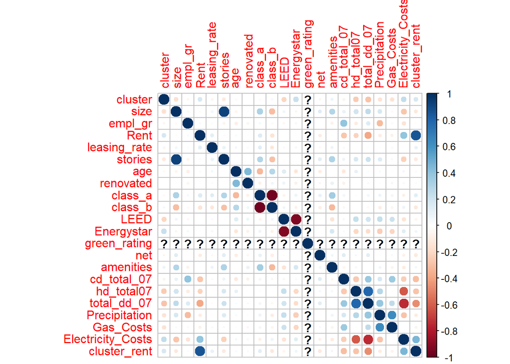

Comments: this helps to show which variables might be correlated to get a better idea of which variables to look at. We see: class, net, cold/hot and total days, and electricity.

#### Net

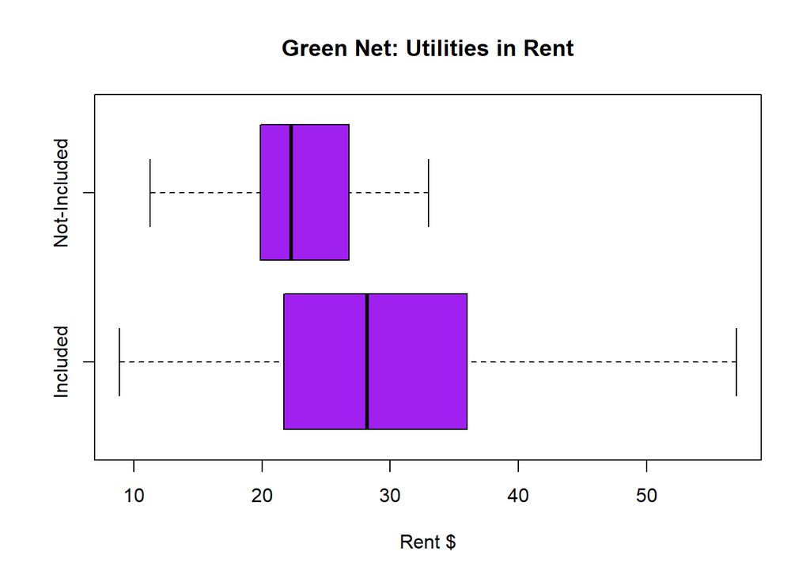

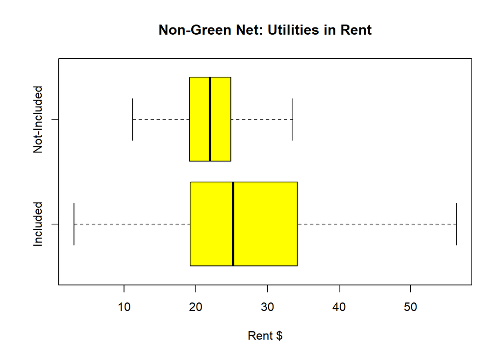

Comments: with Net, we see a big difference- both green and non green have big differences in rent based on net. Seems like rent wise, we should split the groups based on net as well.

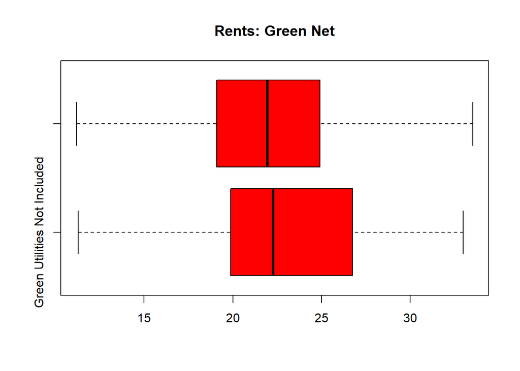

Comments: we see how rent is almost the same for both green and non-green when not including utilities- which is expected

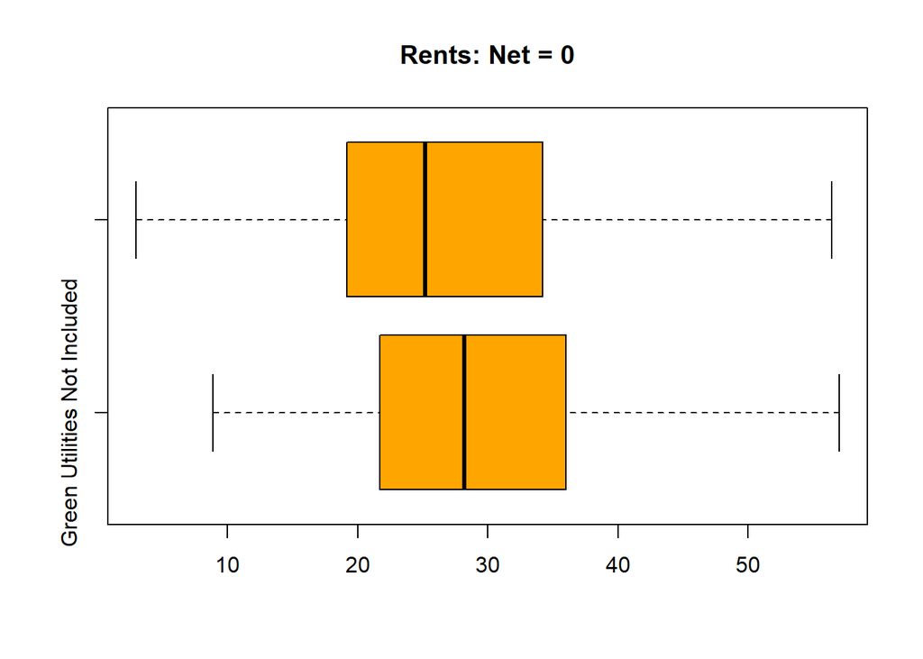

Comments: this is could be a better indicator of the difference between green and non-green rents

#### Amenities

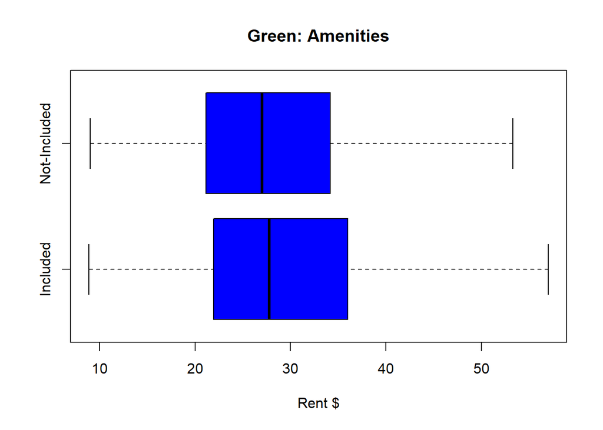

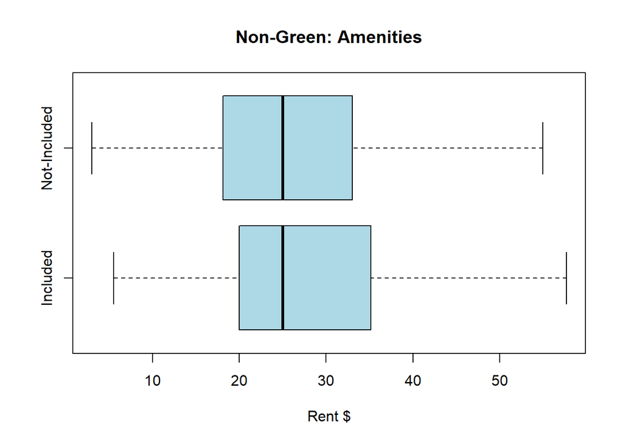

Comments: very similar in rent for both- no significant enough through graph

#### Cluster-Rate

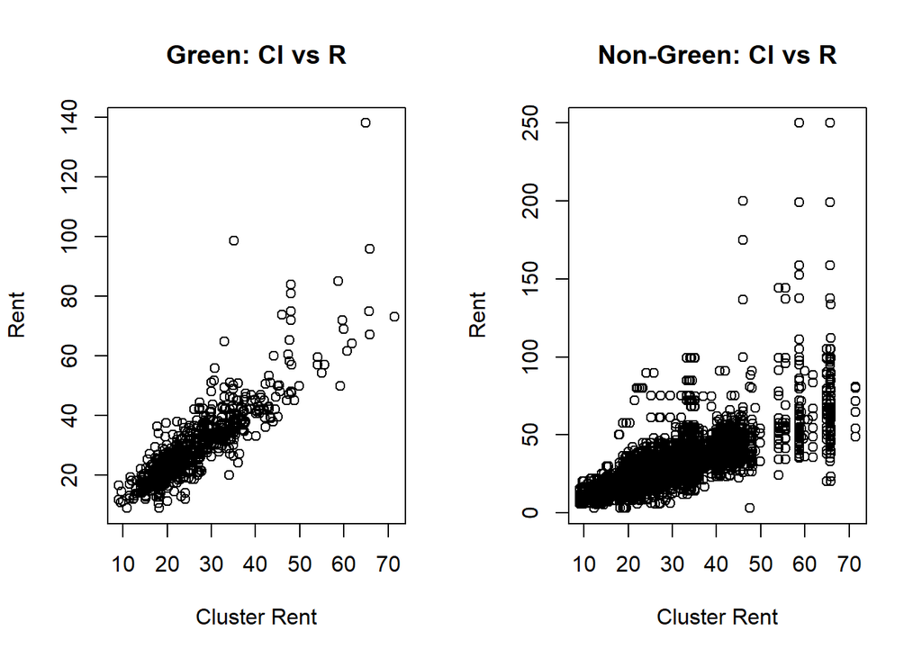

#### Cluster Rate and Utility Costs

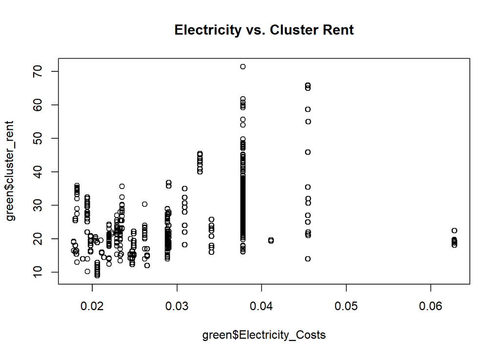

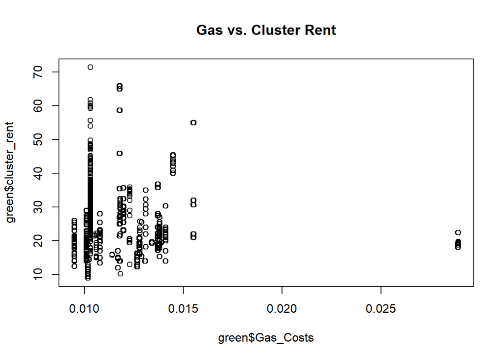

Comments: there seems to be some positive correlation between cluster rent and electricity cost but not really any for gas costs.

#### Leasing

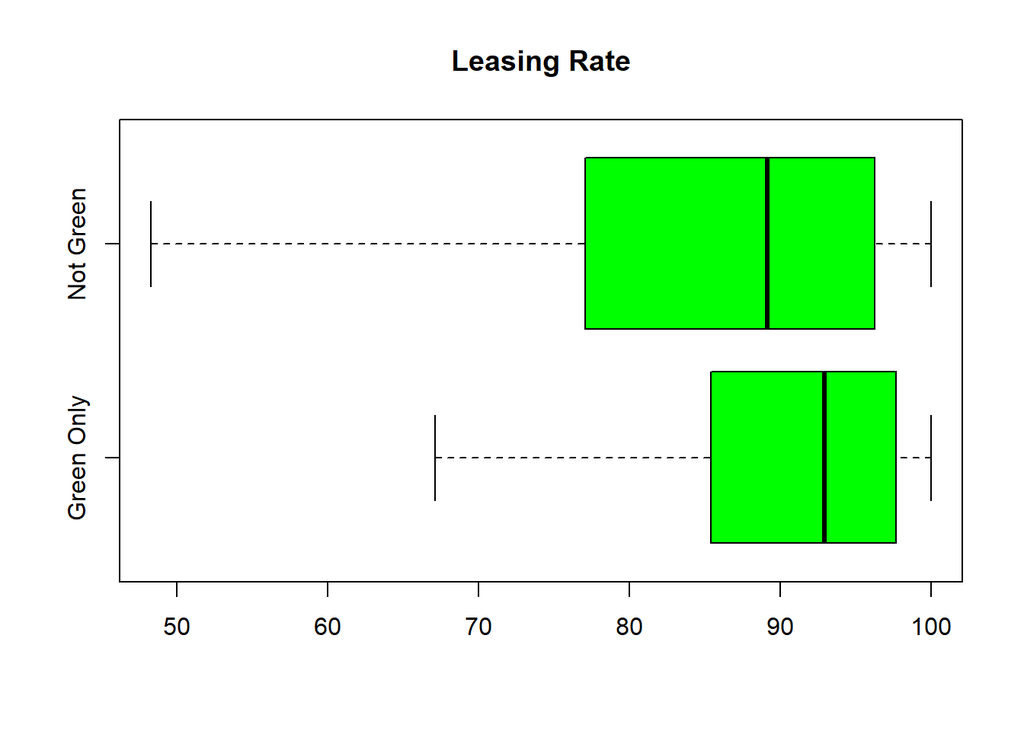

Comments: leasing rate seems to be higher for green buildings. This may confirm that green buildings are more attractive to work in, and also the developer may not have to worry about empty space just sitting there as much as non-green buildings.

#### Class A,B,C

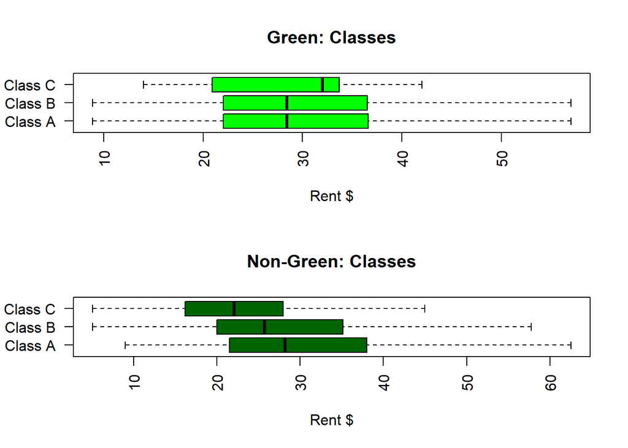

Comments: classes don’t seem to be very different for green except for class c which is very surprising (could just be an anomaly), but since the pattern isn’t apparent, we will not worry about it. But you can easily see positive correlation for non-green classes.

#### Size

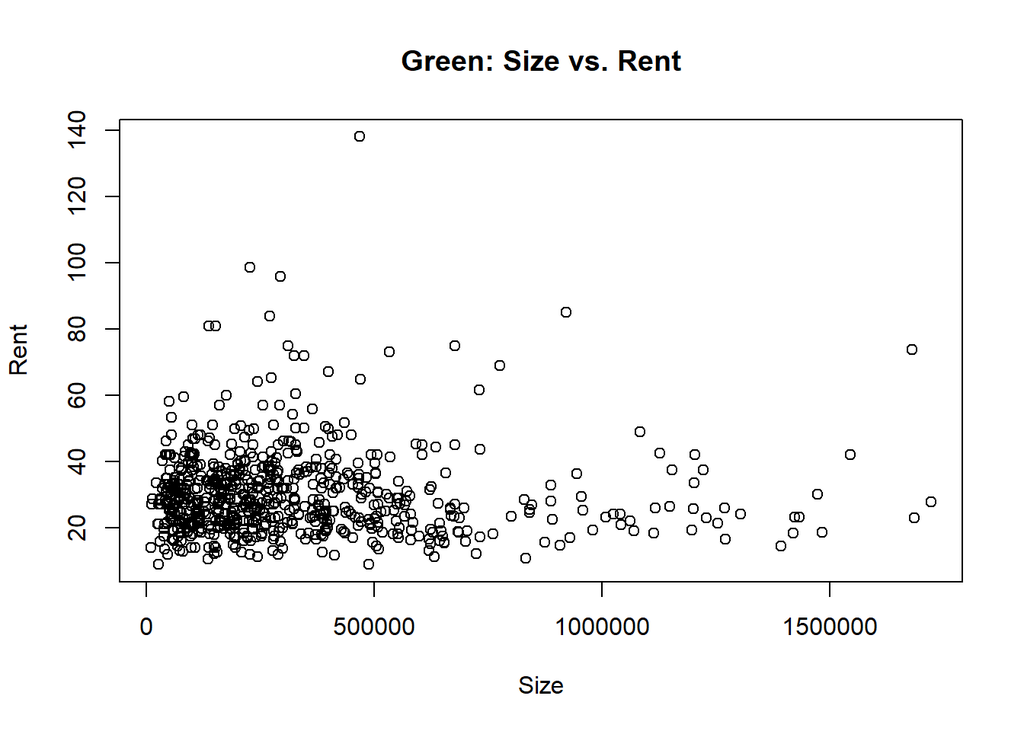

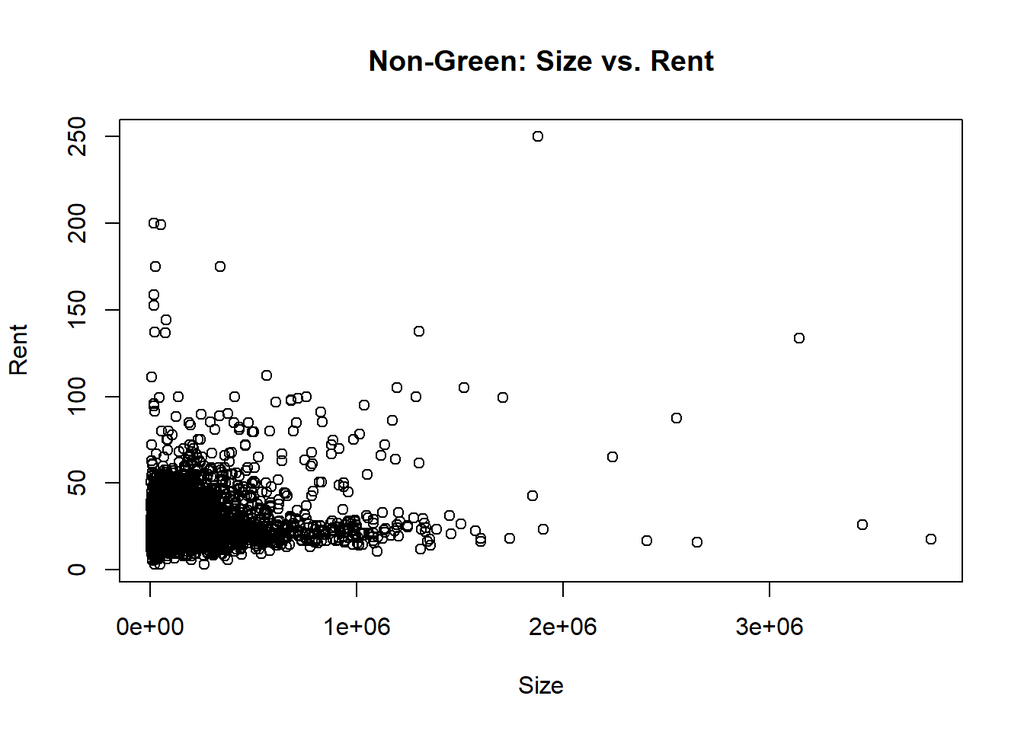

Comments: not really any correlation for all buildings- mostly clustered below 250,000 sqrfeet

### More analysis based on EDA

Using Net to further subset the data into: green_only_net and not_green_net. These include the buildings that do include utilities in the rent.

```r
summary(green_only_net$Rent)
```

```
##    Min. 1st Qu.  Median    Mean 3rd Qu.    Max.
##    8.87   21.69   28.20   30.36   35.98  138.07
```

```r
summary(not_green_net$Rent)
```

```
##    Min. 1st Qu.  Median    Mean 3rd Qu.    Max.
##    2.98   19.20   25.19   28.40   34.20  250.00
```

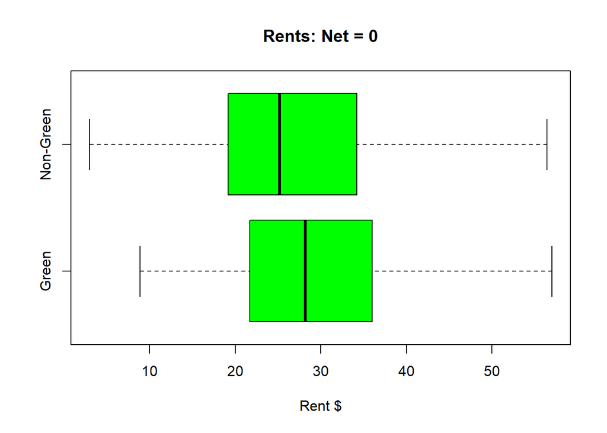

Comments: given the summaries and box plots, we can use these to furter deduce a more accurate difference in overall rent prices.

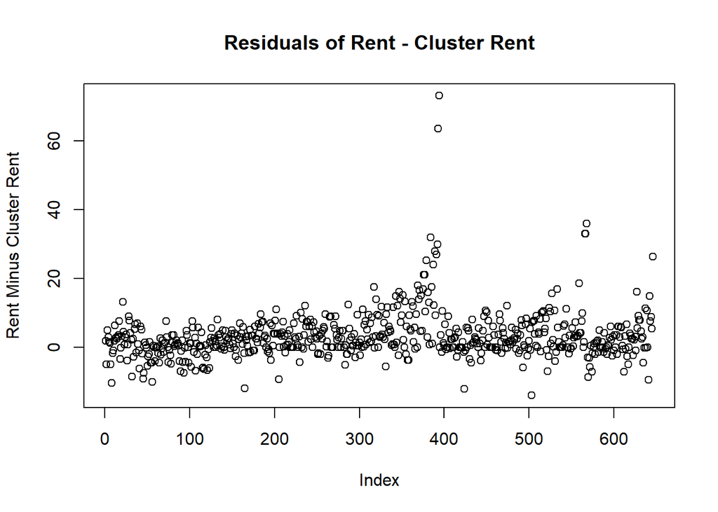

Summary of Rent - Cluster Rent from the green_only_net data

```r
summary(rent_diff)
```

```
##    Min. 1st Qu.  Median    Mean 3rd Qu.    Max.
## -14.000   0.000   2.118   3.187   5.487  73.070
```

Comments: this is another way we could find the difference in the rent prices but this seems a little more bias as it weighs every data point the same- so outliers and other external effects have a stronger effect. This method is more appealing as it accounts for cluster similarities instead of just being general. Location plays an important role in rent and the clusters are the only source of location data.

#### Let’s try bootstrapping the rent difference for a more robust answer

Bootstrap the Rent-Cluster Rent median for the most subsetted table: green_only where net = 0

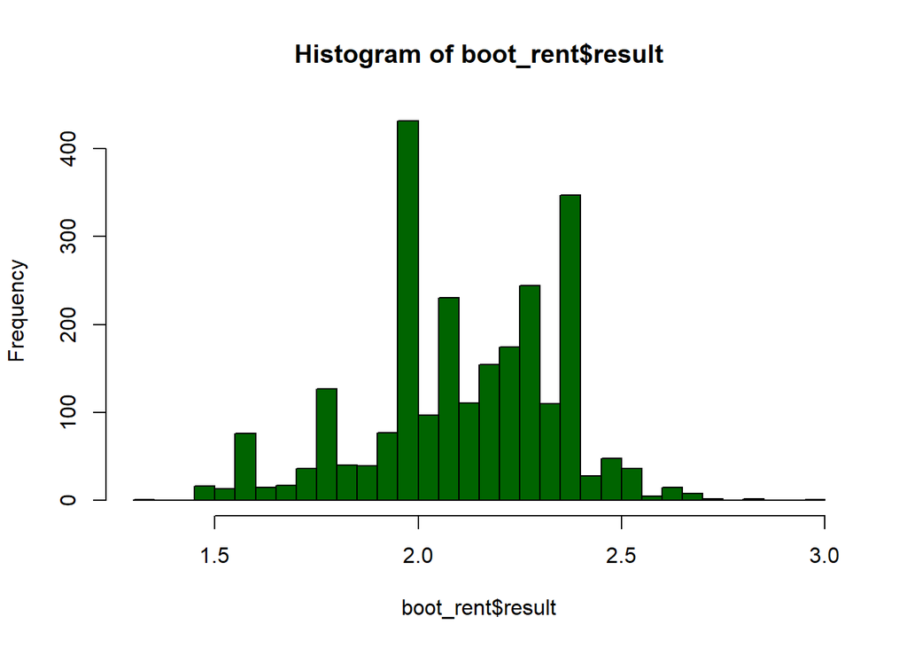

```
##      result
##  Min.   :1.340
##  1st Qu.:2.000
##  Median :2.118
##  Mean   :2.122
##  3rd Qu.:2.300
##  Max.   :2.960
```

We subtracted the subsetted green building cluster rent from the green building actual rent and bootstrapped the median. In this, we leveraged the cluster rent which I believe is more correlated to the green building rent than the overall mean of the non-green building rent.

In conclusion, I do not agree with how the stats-guru got his answer. From our analysis, we see that there are multiple other variables involved in significantly changing the rent of a green building such as presence of utilitie and their prices, cluster rent, hot/cold days (from correlation plot), etc. In this analysis, we saw how net and cluster rent were correlated to the green building rent and we used this knowledge to help us find more evidence of a more accurate profit margin. The analysis can be improved even more by narrowing down our sample to more relevant and similar types of buildings of which we can compare. It would also be a lot of help to get more data from the developer on the type of building she wants to make regarding utilities, class, cluster, etc. It would be the most help to us to find the location of each cluster presented in the data in order to figure out which cluster is closest to the developer’s building’s location.

## Bootstrapping

```
##               ClCl.LQDa    ClCl.TLTa     ClCl.SPYa    ClCl.EEMa
## 2004-09-30 -0.002944009 -0.003837860 -0.0007152540  0.005244650
## 2004-10-01 -0.004428211 -0.004994971  0.0169112381  0.019130453
## 2004-10-04 -0.000631532  0.001486621  0.0016717466  0.017064881
## 2004-10-05  0.004152803  0.000000000  0.0005271082 -0.007382617
## 2004-10-06 -0.002876913 -0.004567276  0.0068480947  0.011550711
## 2004-10-07 -0.002163971 -0.004358763 -0.0107255232 -0.008522252
##                ClCl.VNQa
## 2004-09-30  0.0080241127
## 2004-10-01  0.0185074627
## 2004-10-04  0.0042985932
## 2004-10-05 -0.0001946109
## 2004-10-06  0.0046702083
## 2004-10-07 -0.0102654075
```

```
##                ClCl.LQDa     ClCl.TLTa     ClCl.SPYa    ClCl.EEMa
## 2018-08-03  0.0031263569  0.0049734807  0.0042848222  0.007750171
## 2018-08-06  0.0009523071  0.0005871498  0.0036671685 -0.007690568
## 2018-08-07 -0.0031136567 -0.0051974432  0.0033023185  0.010257602
## 2018-08-08 -0.0015616866  0.0010112328 -0.0004201835 -0.001353836
## 2018-08-09  0.0007820299  0.0084182170 -0.0013661599 -0.002937122
## 2018-08-10  0.0016497613  0.0072627347 -0.0067001191 -0.021300747
##                ClCl.VNQa
## 2018-08-03  0.0108285677
## 2018-08-06 -0.0013240370
## 2018-08-07 -0.0018078944
## 2018-08-08 -0.0057957498
## 2018-08-09  0.0004858028
## 2018-08-10 -0.0076474511
```

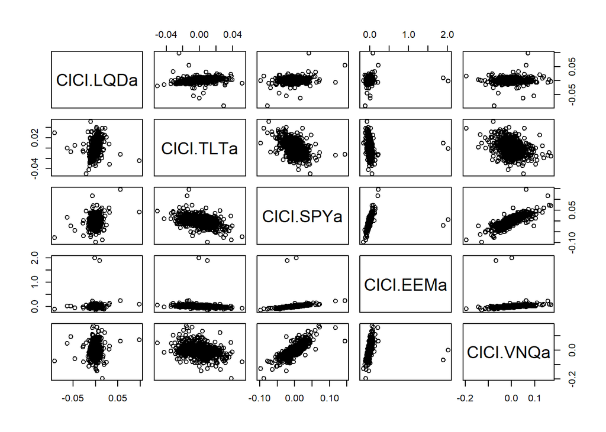

Comment: From this graph we can see the various correlation between the stocks. We can see that the stocks which produce a relatively flat or horizontal line means that one of the variables is more immune to change (ex. LQD)– helpful for portfolio 2 because that means the stock is low risk and low return. We see a positive correlation between VNQ and SPY which might be helpful in the portfolio 3 for high risk and high return.

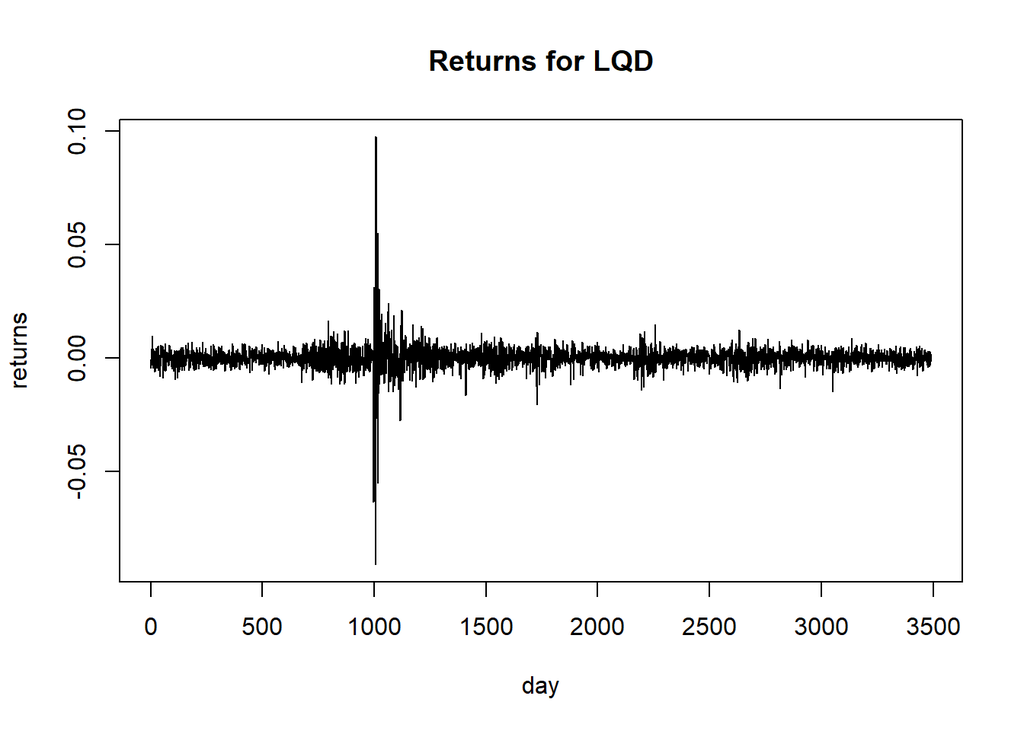

```
##       Min.    1st Qu.     Median       Mean    3rd Qu.       Max.
## -0.0911111 -0.0018985  0.0003581  0.0001916  0.0023453  0.0976772
```

Comment: **Graph** First thing that jumps out at me is the high and low around day: 1000, there was a high positive return as well as a relatively low negative return. However, the remaining points seem to be stable and within a small margin. Looks like a safe stock.  
**Summary** To steer clear of outliers, I look mainly at the median and 1st/3rd Quartiles for the returns. Median is small and quartile range is minimum. Safe stock.

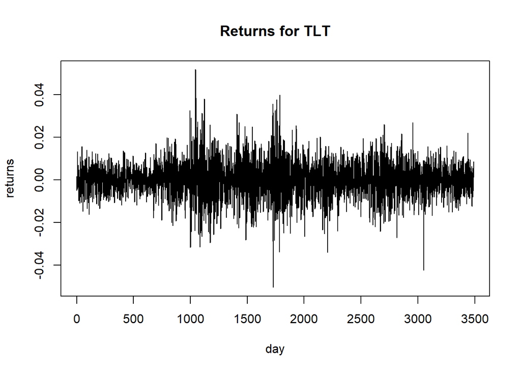

```
##       Min.    1st Qu.     Median       Mean    3rd Qu.       Max.
## -0.0504495 -0.0047801  0.0005119  0.0002656  0.0053240  0.0516616
```

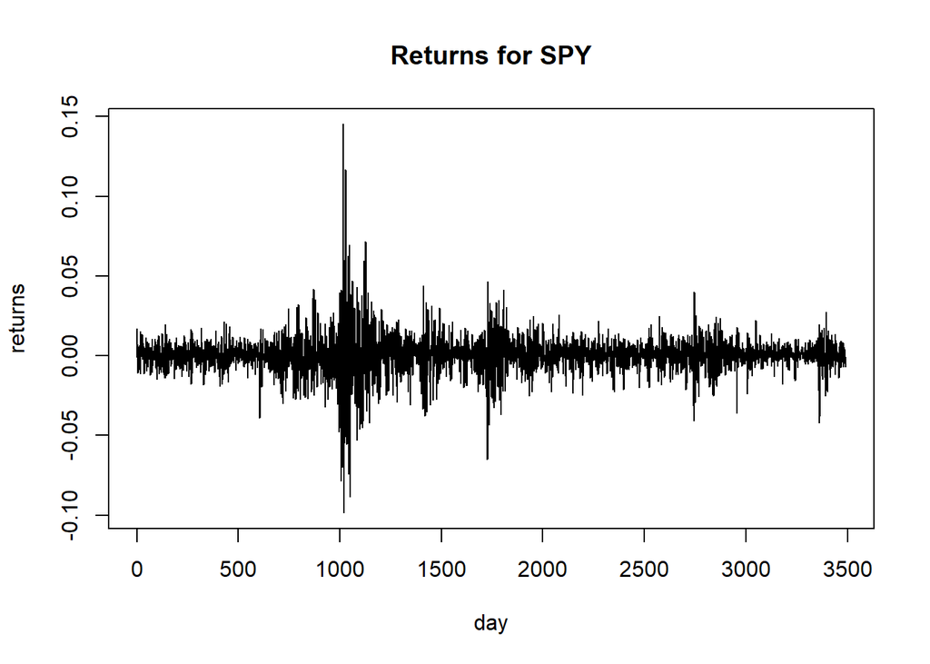

```
##       Min.    1st Qu.     Median       Mean    3rd Qu.       Max.
## -0.0984477 -0.0037570  0.0007041  0.0004143  0.0053883  0.1451977
```

Comment: **Graph** Between day 100 and 1700ish there seems to be some more extreme high and low returns compared to other graphs. This stock seems change a lot but not too much as it is mostly margined between -0.05 and 0.05. Seems like could be either safe or risky. **Summary** Median is larger but quartile range is still relatively small. Safe stock.

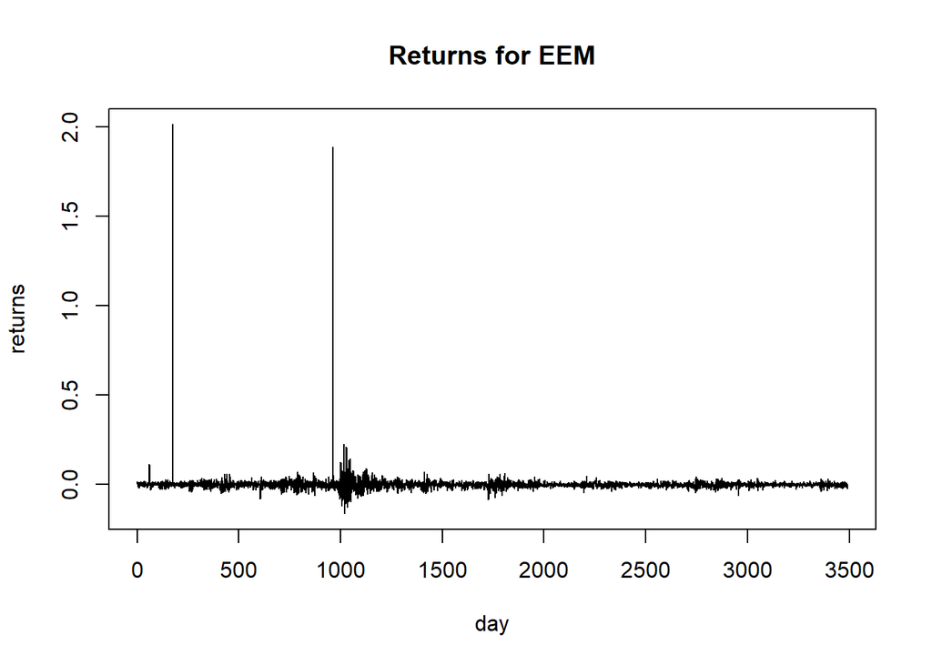

```
##       Min.    1st Qu.     Median       Mean    3rd Qu.       Max.
## -0.1616620 -0.0082770  0.0009536  0.0016786  0.0094616  2.0157291
```

Comment: **Graph** It is hard to tell exactly how the non-outlier days are doing on this graph but when looking at its subsets (ex. days: 1500-3400), the returns are relatively high and low– going above 0.05 and below -0.05. Seems like more of a riskier stock. **Summary** Median is large. Quartile range is much larger comparitively on both negative and positive sides. Risky stock.

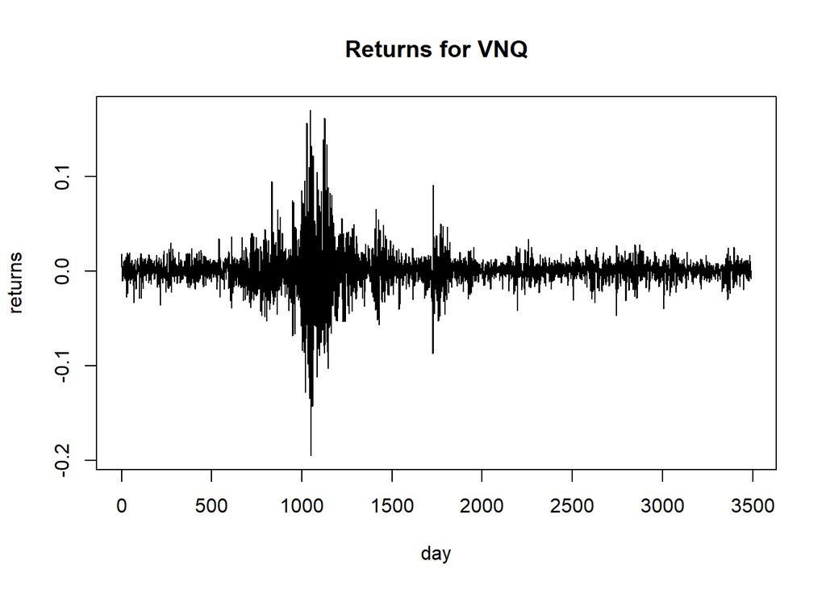

```
##       Min.    1st Qu.     Median       Mean    3rd Qu.       Max.
## -0.1951372 -0.0065597  0.0007728  0.0005096  0.0076721  0.1700654
```

Comment: **Graph** Similar to EEM, this stock has more static and thus seems more volatile. Seems like a riskier stock. **Summary** Similar median to SPY but larger quartile range. Risky stock.

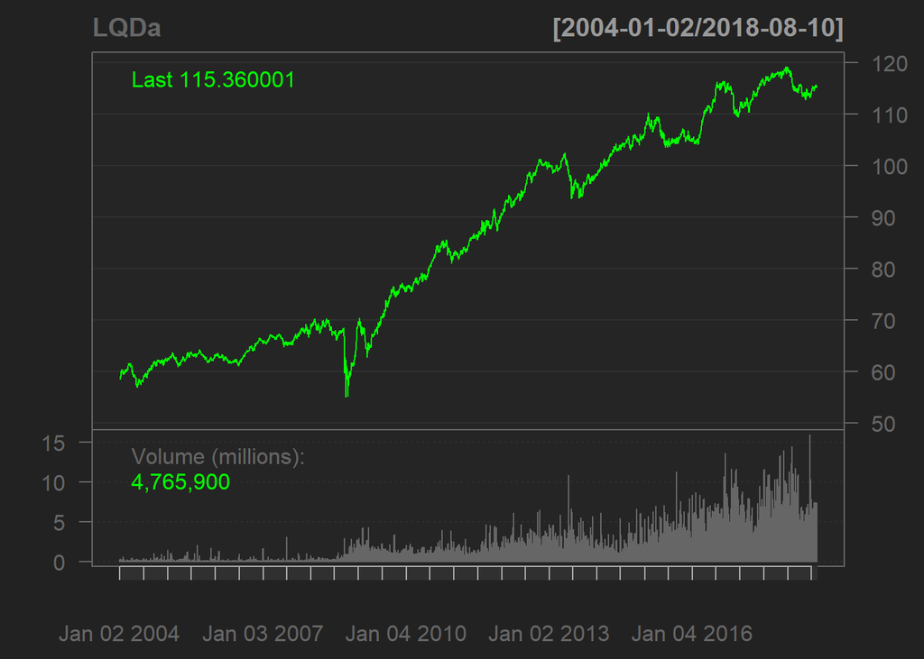

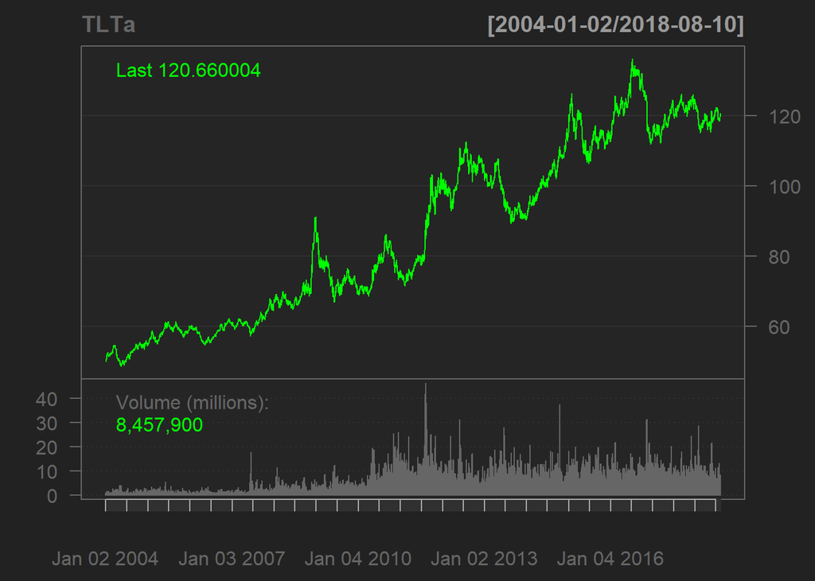

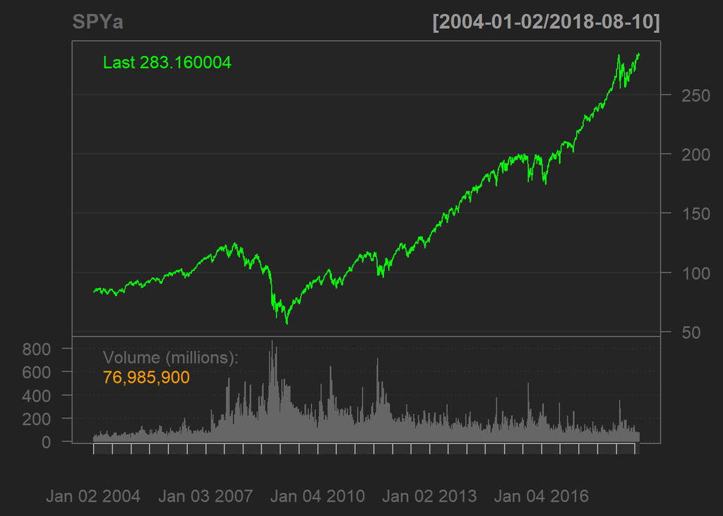

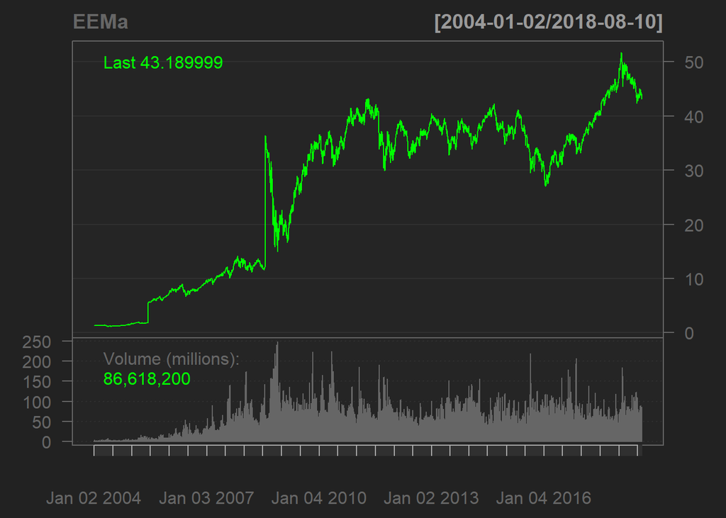

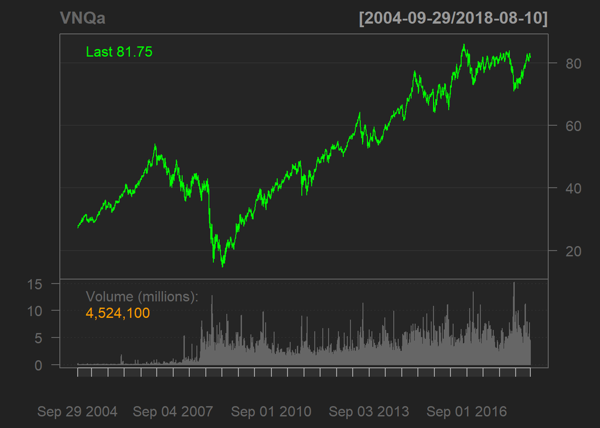

Comment: These chart series graphs show the prices over time. All the graphs seems to match up to my hypothesis described in the previous return graphs except for SPY. The riskier stocks show steep rises and falls of the price. What’s interesting for SPY is that while it looks like a smoother curve, the range for the y-values are 250. There seems to be a solid increase in price but the volatility could be large. I will keep it as a safe stock.

### Portfolio 1

This portfolio splits the wealth and weight evenly among the stocks at 0.2 each. Initial Wealth: $100,000 Runs 5000 times.

Mean wealth: 1.010887410^{5}

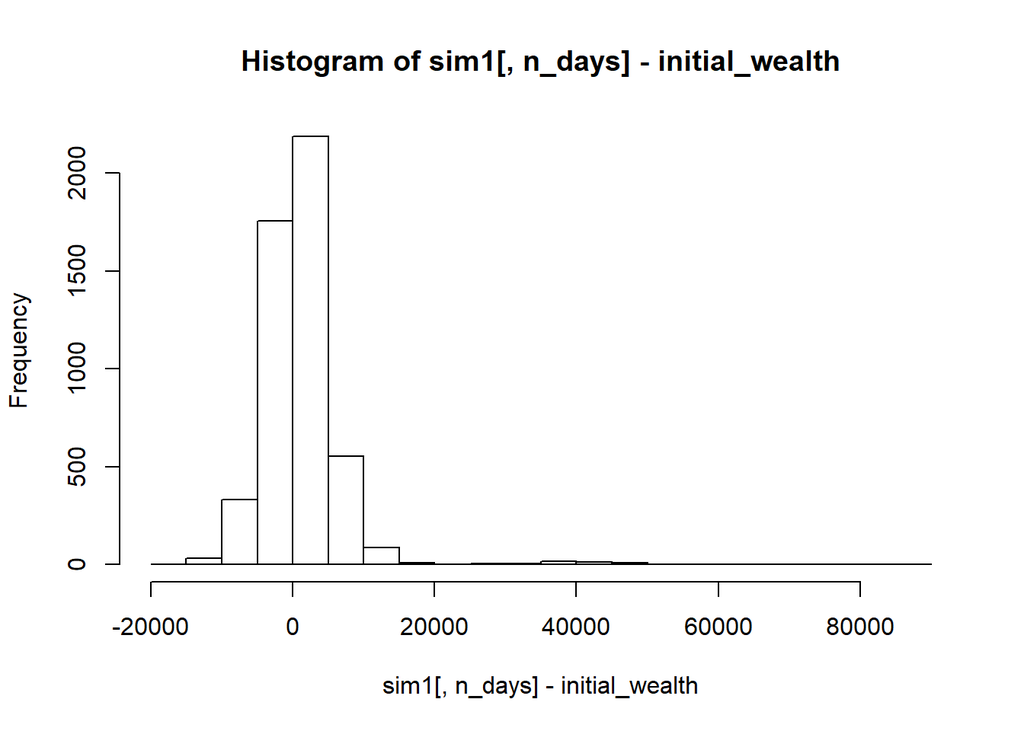

Comment: Graph shows the distribution of returns over the 5000 runs. Mean seems to be greater than 0 with many outlier in the 1000s positive.

Calculate 5% value at risk -5795.4496449 Calculate 95% value at risk 7909.774586

### Portfolio 2

This portfolio leverages something that seems safer than the even split, comprising investments in at least three classes. Stocks used: LQD: 0.35, TLT: 0.3, SPY: 0.35 I selected these weights after many instances of trial and error to find the minimum 5% at risk number. Initial Wealth: $100,000 Runs 5000 times.

Mean wealth: 1.006126810^{5}

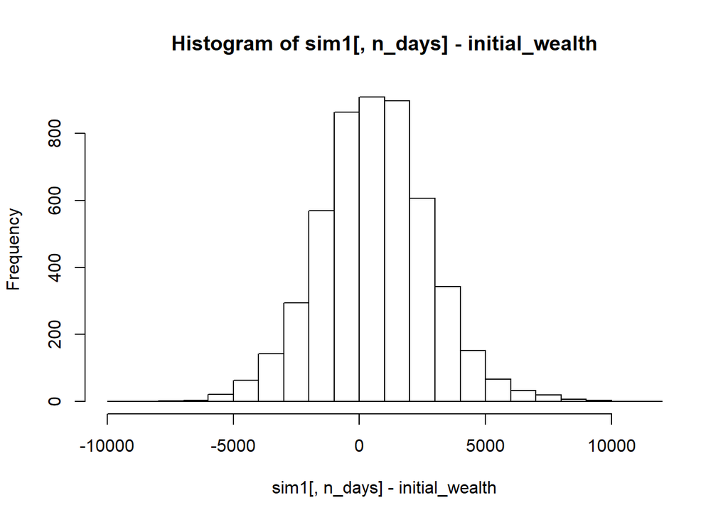

Comment: Graph shows the distribution of returns over the 5000 runs. Mean seems to be very close to 0 with a short distribution from about -$5000 to $7000.

Calculate 5% value at risk -2950.9927336 Calculate 95% value at risk 4154.464743

### Portfolio 3

Stocks used: EEM: 0.8, VNQ: 0.2 I selected these weights after many instances of trial and error to find the maximum lowest 5% and highest 95% at risk number. Initial Wealth: $100,000 Runs 5000 times.

Mean wealth: 1.005701710^{5}

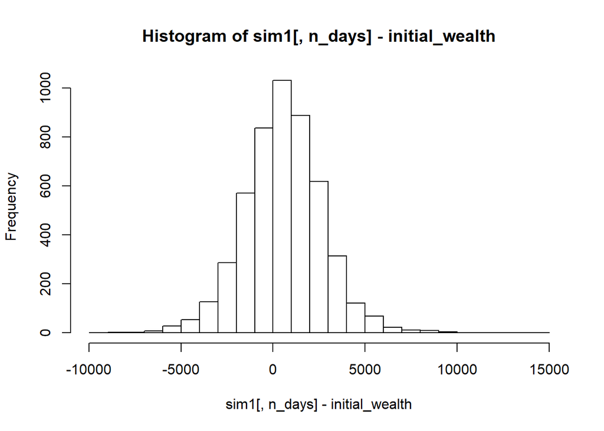

Calculate 5% value at risk -2819.7602608 Calculate 95% value at risk 3957.1704119